# Project 2: Investigate a Dataset - InvestigatingTMDb movie dataset

- Introduction
- Data Wrangling
- Exploratory Data Analysis
- Conclusions
- References

## Introduction

> **TMDb movie dataset**: In this dataset we have about 10,000 movies collected from The Movie Database (TMDb) and it has different features for each movie, we'll investigate the dataset more in depth and we'll try to find different patterns and answer questions we get while investigating!

```python
import pandas as pd
import numpy as np
import matplotlib.pyplot as plt
import seaborn as sns
%matplotlib inline
```

```python
pd.set_option('display.max_columns', None)
pd.set_option('display.max_colwidth', None)
```

### We want to answer different questions about this dataset:

##### 1- What top 5 movies that have high incomes?

> We want to see the names of the movies with the highest incomes and a comparision between them in budget and revenue.

##### 2- Is highest budget means higher revenue?

> We will see if high budget have relationship with revenue and the correleation.

##### 3- What movies have the highest rating?

> What moives that have the highest rating of all time.

## Data Wrangling

### General Properties

```python
tmdb_df = pd.read_csv(r"C:\Users\Moaya\Desktop\Nanodegree projects\Project 2 - Investigate a Dataset\tmdb-movies.csv")
```

```python
# Let's get more familiar with the dataset by finding the rows and columns numbers and also datatypes.
tmdb_df.info()
```

```
<class 'pandas.core.frame.DataFrame'>
RangeIndex: 10866 entries, 0 to 10865
Data columns (total 21 columns):
 #   Column                Non-Null Count  Dtype
---  ------                --------------  -----
 0   id                    10866 non-null  int64
 1   imdb_id               10856 non-null  object
 2   popularity            10866 non-null  float64
 3   budget                10866 non-null  int64
 4   revenue               10866 non-null  int64
 5   original_title        10866 non-null  object
 6   cast                  10790 non-null  object
 7   homepage              2936 non-null   object
 8   director              10822 non-null  object
 9   tagline               8042 non-null   object
 10  keywords              9373 non-null   object
 11  overview              10862 non-null  object
 12  runtime               10866 non-null  int64
 13  genres                10843 non-null  object
 14  production_companies  9836 non-null   object
 15  release_date          10866 non-null  object
 16  vote_count            10866 non-null  int64
 17  vote_average          10866 non-null  float64
 18  release_year          10866 non-null  int64
 19  budget_adj            10866 non-null  float64
 20  revenue_adj           10866 non-null  float64
dtypes: float64(4), int64(6), object(11)
memory usage: 1.7+ MB
```

```python
tmdb_df.sample()
```

|  | id | imdb_id | popularity | budget | revenue | original_title | cast | homepage | director | tagline | keywords | overview | runtime | genres | production_companies | release_date | vote_count | vote_average | release_year | budget_adj | revenue_adj |
| --- | --- | --- | --- | --- | --- | --- | --- | --- | --- | --- | --- | --- | --- | --- | --- | --- | --- | --- | --- | --- | --- |
| 8023 | 535 | tt0085549 | 0.343668 | 4000000 | 92921203 | Flashdance | Jennifer Beals\|Michael Nouri\|Lilia Skala\|Kyle T. Heffner\|Sunny Johnson | NaN | Adrian Lyne | When the dancer becomes the dance. | dancing\|dance\|locksmith\|welder | The popular 1980’s dance movie that depicts the life of an exotic dancer with a side job as a welder who true desire is to get into ballet school. It’s her dream to be a professional dancer and no… | 95 | Drama\|Music\|Romance | Paramount Pictures | 4/14/83 | 149 | 6.1 | 1983 | 8.757248e+06 | 2.034335e+08 |

```python
# We will overwrite the dataframe with some of the existing columns according the questions we asked before,
# to avoid cleaning non-necessary columns.
columns = ['id','original_title','budget','revenue','runtime','release_year','vote_average']
tmdb_df = tmdb_df[columns]
tmdb_df.info()
```

```
<class 'pandas.core.frame.DataFrame'>
RangeIndex: 10866 entries, 0 to 10865
Data columns (total 7 columns):
 #   Column          Non-Null Count  Dtype
---  ------          --------------  -----
 0   id              10866 non-null  int64
 1   original_title  10866 non-null  object
 2   budget          10866 non-null  int64
 3   revenue         10866 non-null  int64
 4   runtime         10866 non-null  int64
 5   release_year    10866 non-null  int64
 6   vote_average    10866 non-null  float64
dtypes: float64(1), int64(5), object(1)
memory usage: 594.4+ KB
```

### Checking for missing values

```python
tmdb_df.describe()
```

|  | id | budget | revenue | runtime | release_year | vote_average |
| --- | --- | --- | --- | --- | --- | --- |
| count | 10866.000000 | 1.086600e+04 | 1.086600e+04 | 10866.000000 | 10866.000000 | 10866.000000 |
| mean | 66064.177434 | 1.462570e+07 | 3.982332e+07 | 102.070863 | 2001.322658 | 5.974922 |
| std | 92130.136561 | 3.091321e+07 | 1.170035e+08 | 31.381405 | 12.812941 | 0.935142 |
| min | 5.000000 | 0.000000e+00 | 0.000000e+00 | 0.000000 | 1960.000000 | 1.500000 |
| 25% | 10596.250000 | 0.000000e+00 | 0.000000e+00 | 90.000000 | 1995.000000 | 5.400000 |
| 50% | 20669.000000 | 0.000000e+00 | 0.000000e+00 | 99.000000 | 2006.000000 | 6.000000 |
| 75% | 75610.000000 | 1.500000e+07 | 2.400000e+07 | 111.000000 | 2011.000000 | 6.600000 |
| max | 417859.000000 | 4.250000e+08 | 2.781506e+09 | 900.000000 | 2015.000000 | 9.200000 |

We can see that for 'budget', 'revenue' and 'runtime' variables has values with minimum of zero! which propably means these're null values. So we have to replace 0 with NaN to be printed.

```python
tmdb_df.replace(0, np.NaN, inplace = True)
```

```python
tmdb_df.isnull().sum()
```

```
id                   0
original_title       0
budget            5696
revenue           6016
runtime             31
release_year         0
vote_average         0
dtype: int64
```

##### However, we do not have to deal with all nulls since we have limited variables we're interested in analyzing.

##### We can delete the columns we do not need to avoid cleaning non-necessary columns.

### Checking for outliers

```python
tmdb_df.describe()
```

|  | id | budget | revenue | runtime | release_year | vote_average |
| --- | --- | --- | --- | --- | --- | --- |
| count | 10866.000000 | 5.170000e+03 | 4.850000e+03 | 10835.000000 | 10866.000000 | 10866.000000 |
| mean | 66064.177434 | 3.073943e+07 | 8.922066e+07 | 102.362898 | 2001.322658 | 5.974922 |
| std | 92130.136561 | 3.890065e+07 | 1.620684e+08 | 30.946957 | 12.812941 | 0.935142 |
| min | 5.000000 | 1.000000e+00 | 2.000000e+00 | 2.000000 | 1960.000000 | 1.500000 |
| 25% | 10596.250000 | 6.000000e+06 | 7.708081e+06 | 90.000000 | 1995.000000 | 5.400000 |
| 50% | 20669.000000 | 1.700000e+07 | 3.182654e+07 | 99.000000 | 2006.000000 | 6.000000 |
| 75% | 75610.000000 | 4.000000e+07 | 9.991823e+07 | 112.000000 | 2011.000000 | 6.600000 |
| max | 417859.000000 | 4.250000e+08 | 2.781506e+09 | 900.000000 | 2015.000000 | 9.200000 |

```python
tmdb_df[tmdb_df['runtime'] > 250].shape[0]
```

```
36
```

We have 36 movies have runtime more than 250 mins (4 hours), so these records should be treated as outliers and removed.

### Checking for duplicates

```python
tmdb_df.duplicated().sum()
```

```
1
```

### Data Cleaning (Removing null values and outliers)

#### Removing Nulls

```python
tmdb_df.isnull().sum()
```

```
id                   0
original_title       0
budget            5696
revenue           6016
runtime             31
release_year         0
vote_average         0
dtype: int64
```

We have more than half of the data is null in 'revenue' and 'budget' variables, so it's not recommended to delete half of your data because many vaiable data will be lost! But we can drop the 'runtime' nulls since it's only few records.

```python
tmdb_df.dropna(subset = ['runtime'], inplace = True)
```

```python
# Now 'runtime' nulls are removed.
tmdb_df.isnull().sum()
```

```
id                   0
original_title       0
budget            5668
revenue           5985
runtime              0
release_year         0
vote_average         0
dtype: int64
```

#### Removing outliers

We will keep all movies that are less than 4 hours in runtime.

```python
tmdb_df = tmdb_df[tmdb_df['runtime'] < 250]
tmdb_df.describe()
```

|  | id | budget | revenue | runtime | release_year | vote_average |
| --- | --- | --- | --- | --- | --- | --- |
| count | 10798.000000 | 5.161000e+03 | 4.847000e+03 | 10798.000000 | 10798.000000 | 10798.000000 |
| mean | 65462.504167 | 3.073932e+07 | 8.924475e+07 | 101.344230 | 2001.287738 | 5.973273 |
| std | 91634.291938 | 3.890614e+07 | 1.621101e+08 | 23.853928 | 12.832038 | 0.934007 |
| min | 5.000000 | 1.000000e+00 | 2.000000e+00 | 2.000000 | 1960.000000 | 1.500000 |
| 25% | 10569.500000 | 6.000000e+06 | 7.716162e+06 | 90.000000 | 1995.000000 | 5.400000 |
| 50% | 20489.000000 | 1.700000e+07 | 3.185308e+07 | 99.000000 | 2006.000000 | 6.000000 |
| 75% | 74496.500000 | 4.000000e+07 | 9.987072e+07 | 111.000000 | 2011.000000 | 6.600000 |
| max | 417859.000000 | 4.250000e+08 | 2.781506e+09 | 248.000000 | 2015.000000 | 8.900000 |

```python
tmdb_df.drop_duplicates(inplace = True)
#Check again to make sure.
tmdb_df.duplicated().sum()
```

```
0
```

## Exploratory Data Analysis

### Research Question 1 - What top 5 movies that have high income?

Creating new column to hold the values of movies income

```python
tmdb_df['income'] = tmdb_df['revenue'] - tmdb_df['budget']
```

```python
#Sorting the values to get the highest income.
tmdb_df.sort_values(by = 'income', ascending = False).head(5)
```

|  | id | original_title | budget | revenue | runtime | release_year | vote_average | income |
| --- | --- | --- | --- | --- | --- | --- | --- | --- |
| 1386 | 19995 | Avatar | 237000000.0 | 2.781506e+09 | 162.0 | 2009 | 7.1 | 2.544506e+09 |
| 3 | 140607 | Star Wars: The Force Awakens | 200000000.0 | 2.068178e+09 | 136.0 | 2015 | 7.5 | 1.868178e+09 |
| 5231 | 597 | Titanic | 200000000.0 | 1.845034e+09 | 194.0 | 1997 | 7.3 | 1.645034e+09 |
| 0 | 135397 | Jurassic World | 150000000.0 | 1.513529e+09 | 124.0 | 2015 | 6.5 | 1.363529e+09 |
| 4 | 168259 | Furious 7 | 190000000.0 | 1.506249e+09 | 137.0 | 2015 | 7.3 | 1.316249e+09 |

We can also see the difference in budget, revenue and income for these top 5 income movies.

### Making a visualization function to be used more than once

```python
def barh(data, title, xlabel, ylabel, recordsNo): #recordsNo holds the number of records to be visualized.
    data.head(recordsNo).plot(kind = 'barh')
    plt.ylabel(ylabel)
    plt.xlabel(xlabel)
    plt.title(title);
```

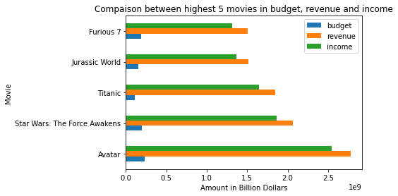

```python
data = tmdb_df.groupby('original_title')['budget', 'revenue', 'income'].mean().sort_values(by = 'income', ascending = False)
barh(data, 'Compaison between highest 5 movies in budget, revenue and income', 'Amount in Billion Dollars', 'Movie', 5)
```